# Wine Quality Analysis

Letian Shi - ISA 616

# 1 Introduction

Within the wine industry, the quality of wine is always one of the most important points to determine the price of the wine. Wines with different qualities have a really big difference on their market value and selling price. The current high-quality and low-quality wine market is very confused, making it difficult to distinguish what is a high-quality wine. It is difficult for the product department of a wine company to buy genuine wines at a reasonable price, which is suitable for drinking wine for their customer groups.

For the product department in the wine company, they want to have a standard of classifying the good-quality wines when buying wines from the vendors. This report uses the white wine and red wine data sets from the Northern Portugal to establish a linear regression model for predicting wine quality score based on the physicochemical properties, so that the product department in the company could use this model to have a standard of choosing suitable wines from wine vendors with good-quality wine and appropriate prices. Instead of the traditional way of deciding wine quality by tasting wine manually, the model would provide a more objective and scientific way to help the product department. By dividing all the data into training data (70%) and testing data (30%), the model is based on training data and uses testing data to evaluate the performances of the prediction model.

# 2 Data Description

Wine Quality data set includes two datasets, related to red and white Vinho Verde wine samples, from the north of Portugal. This data includes several physicochemical measures of wine along with an expert rating of wine quality based on sensory data. The data is from University of California Irvine’s Center of Machine Learning and Intelligent Systems and can be downloaded from the website: https://archive.ics.uci.edu/ml/datasets/wine+quality.

The variables include the following:

- Color (R=red, W=white)
- fixed acidity
- volatile acidity
- citric acid
- residual sugar
- chlorides
- free sulfur dioxide
- total sulfur dioxide
- density
- pH
- sulphates
- alcohol
- quality (score between 0 and 10)

# 3 Data Preprocess

There used to be two separate wine datasets which are red wine and white wine. With creating a new column called “color” to indicate their category, combine them together to get the dataset ready for the analysis later. The new data included 6497 Vinho Verde wine samples and 13 variables in total. There are 11 physicochemical features for the wines and corresponding quality level.

```r
# read the dataset
winequality.red <- read.csv("winequality-red.csv", sep=";")
winequality.white <- read.csv("winequality-white.csv", sep=";")

# add a new variable
library(tidyverse)
red <- winequality.red
white <- winequality.white

library(dplyr)
red <- red%>%
  mutate(color="Red")
white <- white%>%
  mutate(color="White")
wine <- merge(red, white, all=TRUE)

# turn variables into categorical variables
wine$color <- as.factor(wine$color)

# check dataset
str(wine)
```

```
## 'data.frame':    6497 obs. of  13 variables:
##  $ fixed.acidity       : num  3.8 3.9 4.2 4.2 4.4 4.4 4.4 4.5 4.6 4.6 ...
##  $ volatile.acidity    : num  0.31 0.225 0.17 0.215 0.32 0.46 0.54 0.19 0.445 0.52 ...
##  $ citric.acid         : num  0.02 0.4 0.36 0.23 0.39 0.1 0.09 0.21 0 0.15 ...
##  $ residual.sugar      : num  11.1 4.2 1.8 5.1 4.3 2.8 5.1 0.95 1.4 2.1 ...
##  $ chlorides           : num  0.036 0.03 0.029 0.041 0.03 0.024 0.038 0.033 0.053 0.054 ...
##  $ free.sulfur.dioxide : num  20 29 93 64 31 31 52 89 11 8 ...
##  $ total.sulfur.dioxide: num  114 118 161 157 127 111 97 159 178 65 ...
##  $ density             : num  0.992 0.989 0.99 0.997 0.989 ...
##  $ pH                  : num  3.75 3.57 3.65 3.42 3.46 3.48 3.41 3.34 3.79 3.9 ...
##  $ sulphates           : num  0.44 0.36 0.89 0.44 0.36 0.34 0.4 0.42 0.55 0.56 ...
##  $ alcohol             : num  12.4 12.8 12 8 12.8 13.1 12.2 8 10.2 13.1 ...
##  $ quality             : int  6 8 7 3 8 6 7 5 5 4 ...
##  $ color               : Factor w/ 2 levels "Red","White": 2 2 2 2 2 2 2 2 2 1 ...
```

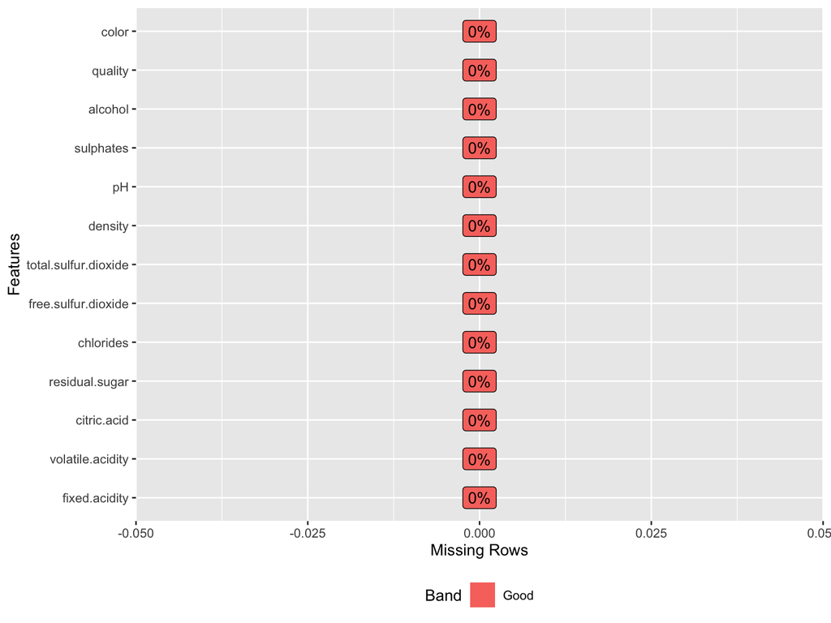

```r
# check missing value
library(DataExplorer)
plot_missing(wine)
```

There are no missing values within the dataset.

```r
# check summary
summary(wine)
```

```
##  fixed.acidity    volatile.acidity  citric.acid     residual.sugar
##  Min.   : 3.800   Min.   :0.0800   Min.   :0.0000   Min.   : 0.600
##  1st Qu.: 6.400   1st Qu.:0.2300   1st Qu.:0.2500   1st Qu.: 1.800
##  Median : 7.000   Median :0.2900   Median :0.3100   Median : 3.000
##  Mean   : 7.215   Mean   :0.3397   Mean   :0.3186   Mean   : 5.443
##  3rd Qu.: 7.700   3rd Qu.:0.4000   3rd Qu.:0.3900   3rd Qu.: 8.100
##  Max.   :15.900   Max.   :1.5800   Max.   :1.6600   Max.   :65.800
##    chlorides       free.sulfur.dioxide total.sulfur.dioxide    density
##  Min.   :0.00900   Min.   :  1.00      Min.   :  6.0        Min.   :0.9871
##  1st Qu.:0.03800   1st Qu.: 17.00      1st Qu.: 77.0        1st Qu.:0.9923
##  Median :0.04700   Median : 29.00      Median :118.0        Median :0.9949
##  Mean   :0.05603   Mean   : 30.53      Mean   :115.7        Mean   :0.9947
##  3rd Qu.:0.06500   3rd Qu.: 41.00      3rd Qu.:156.0        3rd Qu.:0.9970
##  Max.   :0.61100   Max.   :289.00      Max.   :440.0        Max.   :1.0390
##        pH          sulphates         alcohol         quality        color
##  Min.   :2.720   Min.   :0.2200   Min.   : 8.00   Min.   :3.000   Red  :1599
##  1st Qu.:3.110   1st Qu.:0.4300   1st Qu.: 9.50   1st Qu.:5.000   White:4898
##  Median :3.210   Median :0.5100   Median :10.30   Median :6.000
##  Mean   :3.219   Mean   :0.5313   Mean   :10.49   Mean   :5.818
##  3rd Qu.:3.320   3rd Qu.:0.6000   3rd Qu.:11.30   3rd Qu.:6.000
##  Max.   :4.010   Max.   :2.0000   Max.   :14.90   Max.   :9.000
```

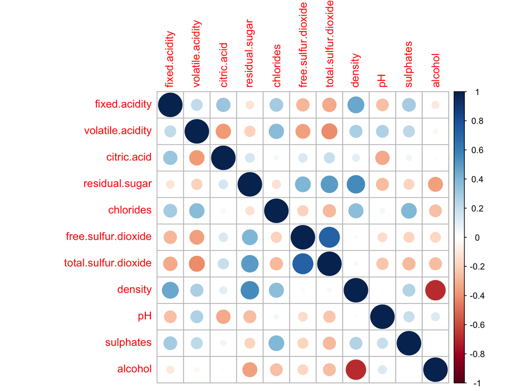

```r
# correlation between variables
library(corrplot)
corr <- cor(wine[,c(1:11)])
corrplot(corr)
```

```r
wine <- wine[,-c(7,8)]
```

# 4 Regression Prediction Model

```r
# training and test sets
set.seed(1)
test.indices <- sample(1:nrow(wine), 0.3*nrow(wine))
wine.train <- wine[-test.indices,]
wine.test <- wine[test.indices,]
```

```r
# build regression model
wine.lm <- lm(quality~., data = wine.train)
summary(wine.lm)
```

```
##
## Call:
## lm(formula = quality ~ ., data = wine.train)
##
## Residuals:
##     Min      1Q  Median      3Q     Max
## -3.6028 -0.4700 -0.0259  0.4598  2.6695
##
## Coefficients:
##                       Estimate Std. Error t value Pr(>|t|)
## (Intercept)          2.8462929  0.3737571   7.615 3.18e-14 ***
## fixed.acidity        0.0011441  0.0125400   0.091 0.927306
## volatile.acidity    -1.6396686  0.1003112 -16.346  < 2e-16 ***
## citric.acid         -0.2143276  0.0960464  -2.232 0.025697 *
## residual.sugar       0.0200133  0.0028134   7.114 1.31e-12 ***
## chlorides           -1.2422916  0.4066994  -3.055 0.002267 **
## free.sulfur.dioxide  0.0028333  0.0007394   3.832 0.000129 ***
## pH                  -0.1023601  0.0869924  -1.177 0.239395
## sulphates            0.4567724  0.0894740   5.105 3.44e-07 ***
## alcohol              0.3605279  0.0107662  33.487  < 2e-16 ***
## colorWhite          -0.3148143  0.0500058  -6.296 3.35e-10 ***
## ---
## Signif. codes:  0 '***' 0.001 '**' 0.01 '*' 0.05 '.' 0.1 ' ' 1
##
## Residual standard error: 0.7468 on 4537 degrees of freedom
## Multiple R-squared:  0.2851, Adjusted R-squared:  0.2836
## F-statistic:   181 on 10 and 4537 DF,  p-value: < 2.2e-16
```

Overall, when controlling for other variables, the higher the residual sugar, free sulfur dioxide, sulphates and alcohol of red wine, the wine quality score would be higher. On the contrary, if the red wine with higher volatile acidity, citric acid, chlorides, pH value, the wine quality score would be lower. The alcohol concentration and volatile acidity are the top two important factors as they have the lowest p-value indicating they have the greatest statistical significance of the wine quality score. This means the product team could pay more attention to these two factors compared with all other factors on wine classification.

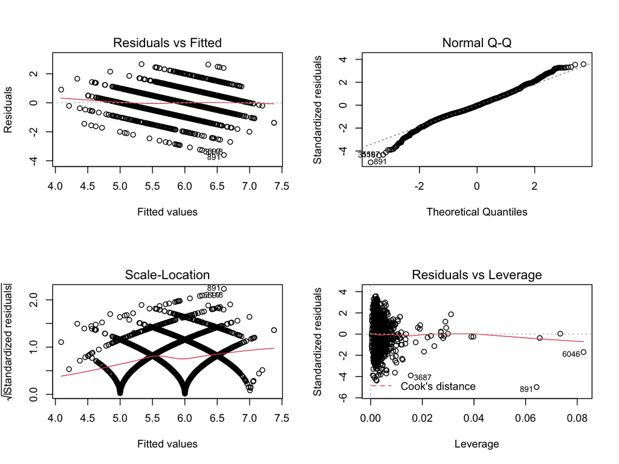

```r
# model diagnosis
par(mfrow=c(2,2))
plot(wine.lm)
```

```r
# prediction
wine.test.pre <- predict(wine.lm, newdata = wine.test)
```

```r
# Calculate the RMSE
library(caret)
RMSE(wine.test.pre, wine.test$quality)
```

```
## [1] 0.71881
```

```r
#R-squared
R2(wine.test.pre, wine.test$quality)
```

```
## [1] 0.2893133
```

The Root Mean Squared Error of the model on testing data is 0.7188.

About 28.93% of the variation in the wine quality score can be explained by the created linear regression model for the testing data.

# 5 Conclusion

With the provided model, it would definitely help the product team to get rid of the issue of relying on professional tasters with their subjective point of view on wine quality. Usually, professional tasters are highly cost, highly time consuming and heavy workload. As tasters need to try all the wine on their own, they could only fit into a small number of high-end markets, not the current highly demanded market. There is about 30% of the variation that could be determined by the predictive model. It is not a perfect number for the product department to set a standard on wine selection from wine vendors. But the product department could combine this model together with their expertise to have a standard on wine selection with an appropriate price.

```r
# References
citation("tidyverse")
```

```
##
##   Wickham et al., (2019). Welcome to the tidyverse. Journal of Open
##   Source Software, 4(43), 1686, https://doi.org/10.21105/joss.01686
##
## A BibTeX entry for LaTeX users is
##
##   @Article{,
##     title = {Welcome to the {tidyverse}},
##     author = {Hadley Wickham and Mara Averick and Jennifer Bryan and Winston Chang and Lucy D'Agostino McGowan and Romain François and Garrett Grolemund and Alex Hayes and Lionel Henry and Jim Hester and Max Kuhn and Thomas Lin Pedersen and Evan Miller and Stephan Milton Bache and Kirill Müller a…
##     year = {2019},
##     journal = {Journal of Open Source Software},
##     volume = {4},
##     number = {43},
##     pages = {1686},
##     doi = {10.21105/joss.01686},
##   }
```

```r
citation("dplyr")
```

```
##
##
##   Hadley Wickham, Romain François, Lionel Henry and Kirill Müller
##   (2020). dplyr: A Grammar of Data Manipulation. R package version
##   1.0.2. https://CRAN.R-project.org/package=dplyr
##
## A BibTeX entry for LaTeX users is
##
##   @Manual{,
##     title = {dplyr: A Grammar of Data Manipulation},
##     author = {Hadley Wickham and Romain François and Lionel {
##              Henry} and Kirill Müller},
##     year = {2020},
##     note = {R package version 1.0.2},
##     url = {https://CRAN.R-project.org/package=dplyr},
##   }
```

```r
citation("DataExplorer")
```

```
##
##
##   Boxuan Cui (2020). DataExplorer: Automate Data Exploration and
##   Treatment. R package version 0.8.1.
##   https://CRAN.R-project.org/package=DataExplorer
##
## A BibTeX entry for LaTeX users is
##
##   @Manual{,
##     title = {DataExplorer: Automate Data Exploration and Treatment},
##     author = {Boxuan Cui},
##     year = {2020},
##     note = {R package version 0.8.1},
##     url = {https://CRAN.R-project.org/package=DataExplorer},
##   }
```

```r
citation("corrplot")
```

```
##
##
##   Taiyun Wei and Viliam Simko (2017). R package "corrplot":
##   Visualization of a Correlation Matrix (Version 0.84). Available from
##   https://github.com/taiyun/corrplot
##
## A BibTeX entry for LaTeX users is
##
##   @Manual{corrplot2017,
##     title = {R package "corrplot": Visualization of a Correlation Matrix},
##     author = {Taiyun Wei and Viliam Simko},
##     year = {2017},
##     note = {(Version 0.84)},
##     url = {https://github.com/taiyun/corrplot},
##   }
```

```r
citation("caret")
```

```
##
##
##   Max Kuhn (2020). caret: Classification and Regression Training. R
##   package version 6.0-86. https://CRAN.R-project.org/package=caret
##
## A BibTeX entry for LaTeX users is
##
##   @Manual{,
##     title = {caret: Classification and Regression Training},
##     author = {Max Kuhn},
##     year = {2020},
##     note = {R package version 6.0-86},
##     url = {https://CRAN.R-project.org/package=caret},
##   }
```